# capture_rates_2

```python
from IPython.display import HTML

HTML('''<script>
code_show=true;
function code_toggle() {
 if (code_show){
 $('div.input').hide();
 } else {
 $('div.input').show();
 }
 code_show = !code_show
}
$( document ).ready(code_toggle);
</script>
<form action="javascript:code_toggle()"><input type="submit" value="Click here to toggle on/off the raw code."></form>''')
```

In these notes we present analytic prescriptions for tidal capture rates as a function of star cluster properties. To develop intuition we start by assuming all stars have the same mass and velocity. Subsequently we allow for a mass and velocity distribution.

**Tidal capture rate (single mass stars and single velocity)**

In order for a black hole of mass $m_{\rm bh}$ to capture a star of mass $m_\star$, the pericenter ($r_p$) must satisfy the following equation

$\frac{1}{2} \mu v^2=T(\eta) \frac{G m_\star^2}{r_\star} \left(\frac{r_p}{r_t}\right)^{-6}$ (1)

$\eta\equiv \sqrt{\frac{m_\star}{m_{\rm bh}+m_\star}} \left(\frac{r_p}{r_\star}\right)^{3/2}$,

where v is the relative velocity, $r_\star$ is the stellar radius, $\mu$ is the reduced mass. $r_t$ is the tidal radius, and $T(\eta) \lesssim 1$ is the tidal coupling constant.

The tidal capture rate of stars by BHs in a cluster is

$\Gamma_{\rm BH-MS}=3.2\times 10^{-6} {\rm pc}^{-3} {\rm yr}^{-1} \left(\frac{n_\star}{10^6 {\rm pc}^{-3}}\right)^2 \left(\frac{f}{10^{-3}}\right)$ $\left(\frac{m_{\rm bh}}{10 M_{\odot}}\right)^{4/3} \left(\frac{v}{10 {\rm km\, \, s^{-1}}}\right)^{-1.2}$ $\left(\frac{m_*}{1 M_{\odot}}\right)^{\alpha}$,

where $n_\star$ is the stellar number density and $f$ is the ratio between BH and stellar number densities (for a typical IMF, $f \sim10^{-3}$). $\alpha$ varies between $\sim$0.2 and 0.5 along the main sequence. The above expression implicitly assumes that the star is less massive than the compact object. For simplicity, we have used the linear tidal coupling constant for a ZAMS, Z=0.02, solar mass star in the above equation (though in reality the tidal coupling constant is a function of the stellar properties). In the third section (**Capture rates integrated over a mass function**), we account for the mass dependence in the tidal coupling constants.

If the star's pericenter is too small the star would be disrupted before it is captured. If we exclude pericenters inside of the tidal radius ($r_t=\left(m_{\rm bh}/m_*\right)^{1/3} r_*$), the rate is reduced by a factor of $\sim$2 for $v=10 \,\,{\rm km\,\, s^{-1}}.$

The rate of tidal capture between two ordinary stars is

$\Gamma_{\rm MS-MS}=1.6\times 10^{-4} {\rm pc}^{-3} {\rm yr}^{-1} \left(\frac{n_\star}{10^6 {\rm pc}^{-3}}\right)^2 $ $\left(\frac{v}{10 {\rm km\, \, s^{-1}}}\right)^{-1.2}$ $\left(\frac{m_*}{1 M_{\odot}}\right)^{1+\beta}$,

where $\beta$ varies between 0.5 and 1 along the main sequence. For simplicity we have assumed that all of the stars are equal mass. The above rate includes physical collisions. For solar mass stars, excluding physical collisions would reduce the capture rate by a factor of 4.6 for v= 10 km s$^{-1}$.

Note that we allow for tidal dissipation in both stars for this case.

**Integrating over a velocity distribution**

In reality the stars and compact objects will have a velocity distribution. We now consider what happens, when the two objects have a Mawellian realtive velocity distribution with a dispersion $\sigma$.

The rate of BH captures for a fixed relative velocity, v, is

$\Gamma_{\rm BH-MS}=\Gamma_o \left[2.2 \left(\frac{v}{10 {\rm\,km\, s^{-1}}}\right)^{-1.2} - \left(\frac{v}{10 {\rm\,km\, s^{-1}}}\right)^{-1}\right],$

where the second term accounts for stars that would be disrupted instead of captured, and

$\Gamma_o=1.47\times 10^{-6} {\rm pc}^{-3} {\rm yr}^{-1} \left(\frac{n_\star}{10^6 {\rm pc}^{-3}}\right)^2 \left(\frac{f}{10^{-3}}\right) \left(\frac{m_{\rm bh}}{10 M_{\odot}}\right)^{4/3} $ $\left(\frac{m_*}{1 M_{\odot}}\right)^{\alpha}$

There will be a velocity, $v_{\rm max}$, above which the star cannot be captured without disruption ($v_{\rm max}\approx 230$ km s$^{-1}$ for a solar type star). The rate integrated over the velocity distribution is

$\tilde{\Gamma}_{\rm BH-MS}= \Gamma_o \left[2.2 g(\sigma)-g_2(\sigma)\right]$ (2),

where $g(\sigma)=\frac{2^{2/5} \left[\gamma \left(\frac{9}{10}\right)-\gamma \left(\frac{9}{10},\frac{v_{\rm max}^2}{2 \sigma^2}\right)\right]}{\sqrt{\pi }} \left(\frac{\sigma}{10 {\rm km s^{-1}}}\right)^{-1.2} $ and

$g_2(\sigma)=\sqrt{\frac{2}{\pi}} \left(1-e^{\frac{-v_{\rm max}^2}{2\sigma^2}}\right) $ $\left(\frac{\sigma}{10 {\rm \,\,km\,\,s^{-1}}}\right)^{-1}$.

$\gamma$ is the Euler Gamma function. The capture rate from eq. (2) is plotted as a black line below. So far to obtain analytic results, we have treated the tidal coupling constant as a power law. The dashed red line shows the capture rate calculated using the exact tidal coupling constant

Similarly, the rate of main sequence captures is

$\tilde{\Gamma}_{\rm MS-MS}= \Gamma_o' \left[1.28 g(\sigma)-g_2(\sigma)\right]$

$\Gamma_o'=1.2\times 10^{-4} \left(\frac{n_\star}{10^6 {\rm pc}^{-3}}\right)^2 \left(\frac{m_*}{1 M_{\odot}}\right)^{1+\beta} $

The second term account accounts for stars the physically collide instead of capture. For two solar type stars, the maximum relative velocity for a capture sans collision is $\sim 33$ km s$^{-1}$. Note that we assume all stars have the same mass.

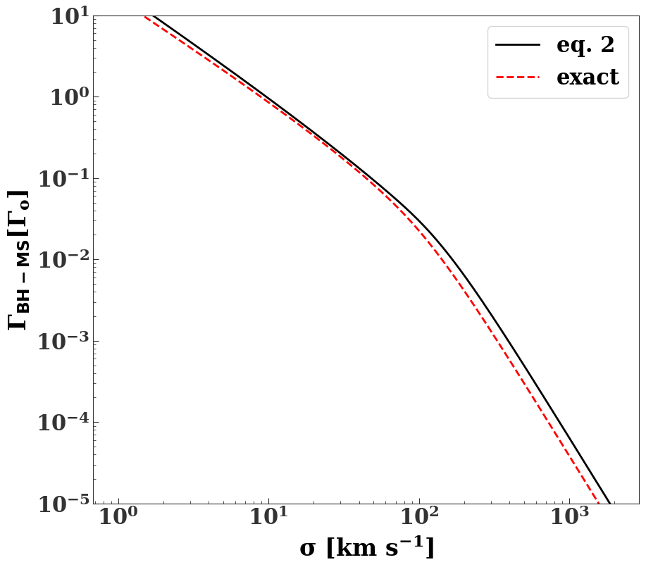

```python
import labelLine
from tidal_coupling_py import exotica
import astropy.units as u
%pylab inline
reload(exotica)

from scipy.special import gamma, gammaincc
from scipy.interpolate import Akima1DInterpolator as akima


sigs=10.**np.arange(5., 8.3, 0.01)
norm=1.47e-6
vmax=2.3e7
fig,ax=plt.subplots(figsize=(10,9))
ax.set_ylim(1.0e-5, 10)
ax.set_ylabel(r'$\Gamma_{\rm BH-MS} [\Gamma_o]$')
ax.set_xlabel(r'$\sigma \,\,[km\,\,s^{-1}]$')

def g1(x):
    return (2**0.4*(gamma(0.9) - gamma(0.9)*gammaincc(0.9,x**2/2.)))/np.sqrt(np.pi)

def g2(x):
    return (2./np.pi)**0.5*(1.-np.exp(-x**2./2.))


nums2=(exotica.get_total_tidal_profile(1.0e3*u.pc**-3., 1.0e6*u.pc**-3, 10.*u.M_sun, 1.*u.M_sun, sigs/1.0e5*u.km/u.s,\
lam_max=6.)).to('pc^-3 yr^-1').value/(norm)
loglog(sigs/1.0e5, (sigs/1.0e6)**-1.*(2.2*g1(vmax/sigs)*(sigs/1.0e6)**-0.2-g2(vmax/sigs)), 'k-', label='eq. 2')
loglog(sigs/1.0e5, nums2, 'r--', label='exact')

ax.legend()
```

**Capture rates integrated over a mass function**

The tidal capture rate integrated over a Kroupa present day mass function (extending between 0.1 and 1 solar masses) is

$\Gamma_{\rm BH-MS}=6 \times 10^{-8} \left(\frac{n_\star}{10^6 {\rm pc}^{-3}}\right)^2 \left(\frac{f}{10^{-3}}\right) \left(\frac{m_{\rm bh}}{10 M_{\odot}}\right)^{4/3} \times $

$\begin{cases} \left(\frac{\sigma}{\sigma_o}\right)^{-1.2} & \sigma <\sigma_o\\ \left(\frac{\sigma}{\sigma_o}\right)^{-3} & \sigma \geq\sigma_o \end{cases}$

$\sigma_o\approx 63 {\rm \,km\,s^{-1}}$

(This is approximately a factor of $\sim 3$ smaller than the capture rate for a population of solar mass stars).

Similarly, the rate of main sequence captures is (integrating over a Kroupa mass function) is

$\Gamma_{\rm MS-MS}= 1.6\times 10^{-6}\left(\frac{n_\star}{10^6 {\rm pc}^{-3}}\right)^2 {\rm pc^{-3} yr^{-1}} \times$

$\begin{cases} \left(\frac{\sigma}{\sigma_o}\right)^{-1.2} & \sigma <\sigma_o\\ \left(\frac{\sigma}{\sigma_o}\right)^{-3} & \sigma \geq\sigma_o \end{cases}$

$\sigma_o\approx 40 {\rm \,km\,s^{-1}}$

For comparison the capture rate for a population of main sequence stars is

$\Gamma_{\rm MS-MS}= 7.6\times 10^{-5}\left(\frac{n_\star}{10^6 {\rm pc}^{-3}}\right)^2 {\rm pc^{-3} yr^{-1}} \times$

$\begin{cases} \left(\frac{\sigma}{\sigma_o}\right)^{-1.2} & \sigma <\sigma_o\\ \left(\frac{\sigma}{\sigma_o}\right)^{-3} & \sigma \geq\sigma_o \end{cases}$

$\sigma_o\approx 14 {\rm \,km\,s^{-1}}$

For this section we have used the tabulated tidal coupling constants [here](https://github.com/alekseygenerozov/zams_tidal_coupling/blob/master/README.md). These are computed using linear theory and neglect non-linear effects (to our knowledge no one has computed non-linear tidal coupling constants for realistic stellar models).

For pericenters too close to the tidal radius, the star will lose a significant fraction of its mass, and would likely be destroyed in a series of partial disruptions. In practice, we exclude pericenters inside of $1.6 r_t$ ($r_t$) for stars below (above) 0.7 solar masses. For such cases, the star would lose $\gtrsim$ 10% of its mass after the first pericenter passage (see [Mainetti et al. 2017](https://www.aanda.org/articles/aa/pdf/2017/04/aa30092-16.pdf)).

**Comparison to other processes**

*3-body capture* The rate of 3-body captures is approximately

$\Gamma_{3}\approx \frac{G^5 m^5}{\sigma^9} n^3=$

$1.5\times 10^{-9} {\rm \,pc^{-3}\,yr^{-1}} \left(\frac{n}{10^6 {\rm \,pc^{-3}}}\right)^3 \left(\frac{\sigma}{10 {\rm \,km\,s}}\right)^{-9} \left(\frac{M}{1 M_{\odot}}\right)^5$

```python
import labelLine
from tidal_coupling_py import exotica
import astropy.units as u
%pylab inline
reload(exotica)

from scipy.special import gamma, gammaincc
from scipy.interpolate import Akima1DInterpolator as akima


norm=1.47e-6
sigs=10.**np.arange(5., 8., 0.01)

# fig,ax=plt.subplots(figsize=(10,9))
# ax.set_ylim(1.0e-5, 10)
# ax.set_ylabel(r'$\Gamma_{\rm BH-MS} [\Gamma_o]$')
# ax.set_xlabel(r'$\sigma \,\,[km\,\,s^{-1}]$')

def g1(x):
    return (2**0.4*(gamma(0.9) - gamma(0.9)*gammaincc(0.9,x**2/2.)))/np.sqrt(np.pi)

def g2(x):
    return (2./np.pi)**0.5*(1.-np.exp(-x**2./2.))

ms=np.logspace(-1., 0.)
rates_avg=[exotica.mu_kroupa(mm*u.M_sun).to('1/solMass').value\
           *exotica.get_total_tidal_profile(1.0e3*u.pc**-3., 1.0e6*u.pc**-3, 10.*u.M_sun, mm*u.M_sun, sigs/1.0e5*u.km/u.s).to('pc**-3*yr**-1').value\
           for mm in ms]
mus=[exotica.mu_kroupa(mm*u.M_sun).to('1/solMass').value for mm in ms]
rates_avg=np.array(rates_avg)

rate_integ=akima(ms, rates_avg).antiderivative()(ms[-1])-akima(ms, rates_avg).antiderivative()(ms[0])
norm2=akima(ms, mus).antiderivative()(ms[-1])-akima(ms, mus).antiderivative()(ms[0])
```

Capture rates of stars by stellar mass black holes for different mass functions. $n_\star=10^6$ pc$^{-3}$, $n_{\rm bh}=10^3$ pc$^{-3}$, and $m_{\rm bh}=10 M_{\odot}$.

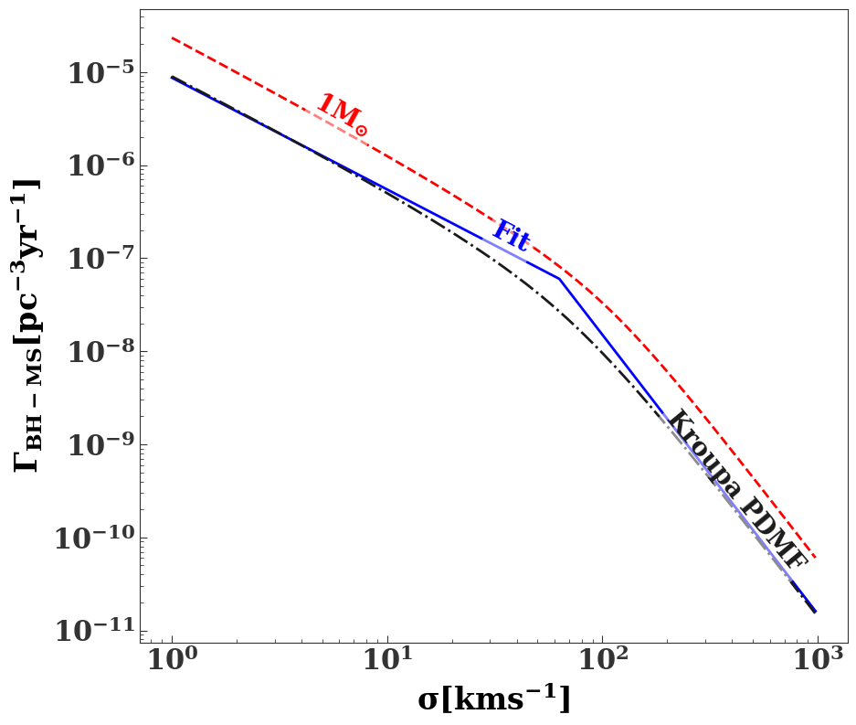

```python
norm=1.47e-6
@np.vectorize
def rate_fit_simple(sig, sig0, norm):
    if sig<sig0:
        return norm*(sig/sig0)**-1.2
    else:
        return norm*(sig/sig0)**-3.

fig,ax=plt.subplots(figsize=(10,9))
ax.set_xlabel(r'$\sigma [km s^{-1}]$')
ax.set_ylabel(r'$\Gamma_{BH-MS} [pc^{-3} yr^{-1}]$')
# loglog(sigs/1.0e5, rate_integ/norm/norm2, '-.')

nums2=(exotica.get_total_tidal_profile(1.0e3*u.pc**-3., 1.0e6*u.pc**-3, 10.*u.M_sun, 1.*u.M_sun, sigs/1.0e5*u.km/u.s,\
lam_max=6.)).to('pc^-3 yr^-1').value
l0,=loglog(sigs/1.0e5, nums2, 'r--', label=r'$1 M_{\odot}$')

vmax=2.3e7
# xs=vmax/sigs
# ys=rate_integ/norm/norm2
l1,=loglog(sigs/1.0e5, rate_fit_simple(sigs/1.0e5, 63., 0.041*norm), 'b-', label=r'Fit')

l2,=loglog(sigs/1.0e5, rate_integ/norm2, '-.', label='Kroupa PDMF')
labelLine.labelLines([l0, l1, l2], fontsize=20)
```

Rates of stars capturing each other for different mass functions. $n_\star=10^6$ pc$^{-3}$

```python
##Integrating capture rate of normal stars over mass function

import labelLine
from tidal_coupling_py import exotica
import astropy.units as u
%pylab inline

from scipy.special import gamma, gammaincc
from scipy.interpolate import Akima1DInterpolator as akima
reload(exotica)

m_ords=np.arange(0.11, 1., 0.05)
m_ords2=np.arange(0.1, 1., 0.02)

sigs=10.**np.arange(5., 8., 0.01)
imf=exotica.mu_kroupa
rate_integs=np.empty([len(m_ords), len(sigs)])
norm2=0.88

for jj,mm in enumerate(m_ords):
    qs=np.arange(m_ords2[0]/mm, 1., 0.02)
    ms=qs*mm
    nums=[exotica.get_total_tidal_profile_stars(1.0e6*u.pc**-3., 1.0e6*u.pc**-3, mm*u.M_sun,q*mm*u.M_sun, sigs/1.0e5*u.km/u.s).to('pc^-3*yr^-1').value\
          for q in qs]
    nums=np.array(nums)

    rates_avg=[imf(ms[ii]*u.M_sun).to('1/solMass').value*nums[ii] for ii in range(len(ms))]
    rate_integs[jj]=akima(ms, rates_avg).antiderivative()(ms[-1])-akima(ms, rates_avg).antiderivative()(ms[0])

    rate_integs[jj]=rate_integs[jj]/norm2
```

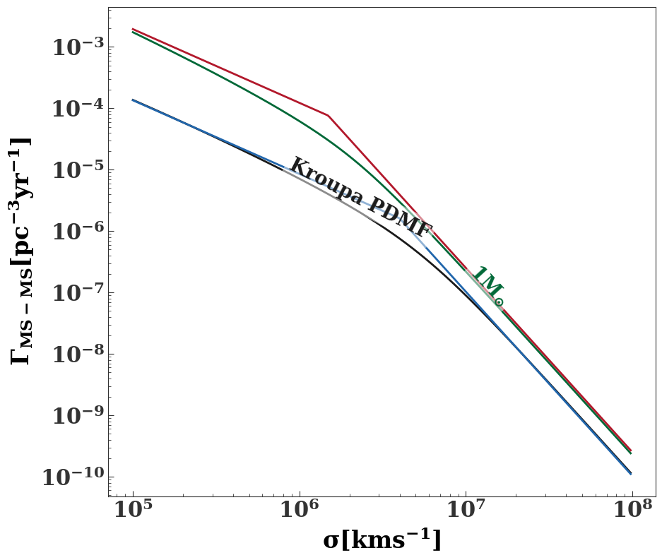

```python
# @np.vectorize
# def rate_fit_simple(sig, sig0, norm):
#     if sig<sig0:
#         return norm*(sig/sig0)**-1.2
#     else:
#         return norm*(sig/sig0)**-3.

fig,ax=plt.subplots(figsize=(10,9))
ax.set_xlabel(r'$\sigma [km s^{-1}]$')
ax.set_ylabel(r'$\Gamma_{MS-MS} [pc^{-3} yr^{-1}]$')

comp2=exotica.get_total_tidal_profile_stars(1.0e6*u.pc**-3., 1.0e6*u.pc**-3,1.*u.M_sun,1.*u.M_sun, sigs/1.0e5*u.km/u.s).to('pc^-3*yr^-1').value

rates_avg2=[imf(m_ords[ii]*u.M_sun).to('1/solMass').value*rate_integs[ii] for ii in range(len(m_ords))]
rate_integs2=akima(m_ords, rates_avg2).antiderivative()(m_ords[-1])-akima(m_ords, rates_avg2).antiderivative()(m_ords[0])

l1,=loglog(sigs, rate_integs2/norm2, label='Kroupa PDMF')
loglog(sigs, rate_fit_simple(sigs/1.0e5, 40., 1.42e-6/norm2))


l2,=loglog(sigs,comp2, label=r'$1 M_{\odot}$')
loglog(sigs, rate_fit_simple(sigs/1.0e5, 14.9, 7.6e-5))

labelLine.labelLines([l1, l2], fontsize=20)
```

```python
1.42e-6/0.88
```

```
1.6136363636363635e-06
```